# Project 4 : Exploration of Red Wine Quality

Isabel María Villalba Jiménez

December 6th, 2016

# 1 Analysis

In this work it will be analyzed the impact in quality of several parameters describing red wine. The dataset is curated by Udacity and comes from UCI repository https://archive.ics.uci.edu/ml/datasets/Wine+Quality and consists of 1599 sample data for Red wine https://docs.google.com/document/d/1qEcwltBMlRYZT-l699-71TzInWfk4W9q5rTCSvDVMpc/pub?embedded=true.

In Cortez et al. (2009) it is shown that the most imporant features for assessing Red Wine quality are:

- sulphates
- pH
- total sulfur dioxide

# 2 Variable summary

```r
# Load the Data
redwines <- read.csv('wineQualityReds.csv')

dim(redwines)
```

```
## [1] 1599   13
```

```r
#names(redwines)
summary(redwines)
```

```
##        X          fixed.acidity   volatile.acidity  citric.acid
##  Min.   :   1.0   Min.   : 4.60   Min.   :0.1200   Min.   :0.000
##  1st Qu.: 400.5   1st Qu.: 7.10   1st Qu.:0.3900   1st Qu.:0.090
##  Median : 800.0   Median : 7.90   Median :0.5200   Median :0.260
##  Mean   : 800.0   Mean   : 8.32   Mean   :0.5278   Mean   :0.271
##  3rd Qu.:1199.5   3rd Qu.: 9.20   3rd Qu.:0.6400   3rd Qu.:0.420
##  Max.   :1599.0   Max.   :15.90   Max.   :1.5800   Max.   :1.000
##  residual.sugar     chlorides       free.sulfur.dioxide
##  Min.   : 0.900   Min.   :0.01200   Min.   : 1.00
##  1st Qu.: 1.900   1st Qu.:0.07000   1st Qu.: 7.00
##  Median : 2.200   Median :0.07900   Median :14.00
##  Mean   : 2.539   Mean   :0.08747   Mean   :15.87
##  3rd Qu.: 2.600   3rd Qu.:0.09000   3rd Qu.:21.00
##  Max.   :15.500   Max.   :0.61100   Max.   :72.00
##  total.sulfur.dioxide    density             pH          sulphates
##  Min.   :  6.00       Min.   :0.9901   Min.   :2.740   Min.   :0.3300
##  1st Qu.: 22.00       1st Qu.:0.9956   1st Qu.:3.210   1st Qu.:0.5500
##  Median : 38.00       Median :0.9968   Median :3.310   Median :0.6200
##  Mean   : 46.47       Mean   :0.9967   Mean   :3.311   Mean   :0.6581
##  3rd Qu.: 62.00       3rd Qu.:0.9978   3rd Qu.:3.400   3rd Qu.:0.7300
##  Max.   :289.00       Max.   :1.0037   Max.   :4.010   Max.   :2.0000
##     alcohol         quality
##  Min.   : 8.40   Min.   :3.000
##  1st Qu.: 9.50   1st Qu.:5.000
##  Median :10.20   Median :6.000
##  Mean   :10.42   Mean   :5.636
##  3rd Qu.:11.10   3rd Qu.:6.000
##  Max.   :14.90   Max.   :8.000
```

```r
# New variables
#redwines$quality.factor <- factor(redwines$quality)

redwines$quality.cat <- NA
redwines$quality.cat <- ifelse(redwines$quality>=7, 'good','medium')
redwines$quality.cat <- ifelse(redwines$quality<=4, 'bad',redwines$quality.cat) # if not, leave the previous values
redwines$quality.cat <- factor(redwines$quality.cat, levels = list('bad', 'medium','good')) # set the order!

print("Variables after dividing into quality groups")
```

```
## [1] "Variables after dividing into quality groups"
```

```r
str(redwines) #summary of values for each variable
```

```
## 'data.frame':    1599 obs. of  14 variables:
##  $ X                   : int  1 2 3 4 5 6 7 8 9 10 ...
##  $ fixed.acidity       : num  7.4 7.8 7.8 11.2 7.4 7.4 7.9 7.3 7.8 7.5 ...
##  $ volatile.acidity    : num  0.7 0.88 0.76 0.28 0.7 0.66 0.6 0.65 0.58 0.5 ...
##  $ citric.acid         : num  0 0 0.04 0.56 0 0 0.06 0 0.02 0.36 ...
##  $ residual.sugar      : num  1.9 2.6 2.3 1.9 1.9 1.8 1.6 1.2 2 6.1 ...
##  $ chlorides           : num  0.076 0.098 0.092 0.075 0.076 0.075 0.069 0.065 0.073 0.071 ...
##  $ free.sulfur.dioxide : num  11 25 15 17 11 13 15 15 9 17 ...
##  $ total.sulfur.dioxide: num  34 67 54 60 34 40 59 21 18 102 ...
##  $ density             : num  0.998 0.997 0.997 0.998 0.998 ...
##  $ pH                  : num  3.51 3.2 3.26 3.16 3.51 3.51 3.3 3.39 3.36 3.35 ...
##  $ sulphates           : num  0.56 0.68 0.65 0.58 0.56 0.56 0.46 0.47 0.57 0.8 ...
##  $ alcohol             : num  9.4 9.8 9.8 9.8 9.4 9.4 9.4 10 9.5 10.5 ...
##  $ quality             : int  5 5 5 6 5 5 5 7 7 5 ...
##  $ quality.cat         : Factor w/ 3 levels "bad","medium",..: 2 2 2 2 2 2 2 3 3 2 ...
```

```r
#unique(redwines$quality.cat)
```

# 3 Univariate analysis

In this section it will be analyzed each of the variables describing the wines.

## 3.1 Plots Section

### 3.1.1 Quality

The distribution of wine shows that most of wines have a quality between 5-6 points.

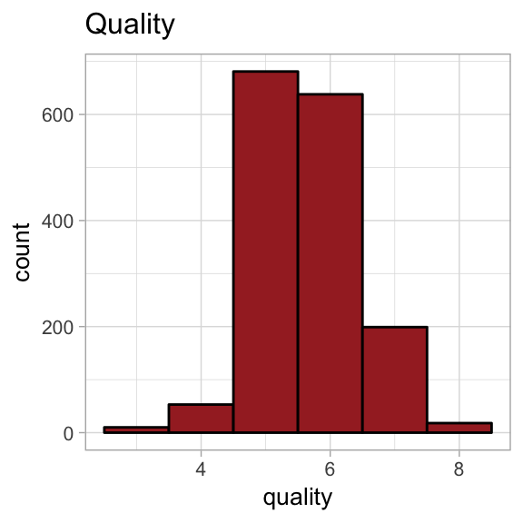

Figure 3.1: Quality distribution

### 3.1.2 Fixed and volatile acidity

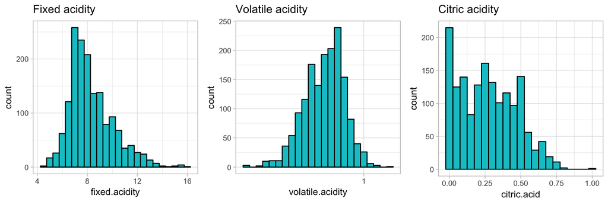

Figure 3.2: Fixed and volatile acidity distributions

### 3.1.3 Residual sugar

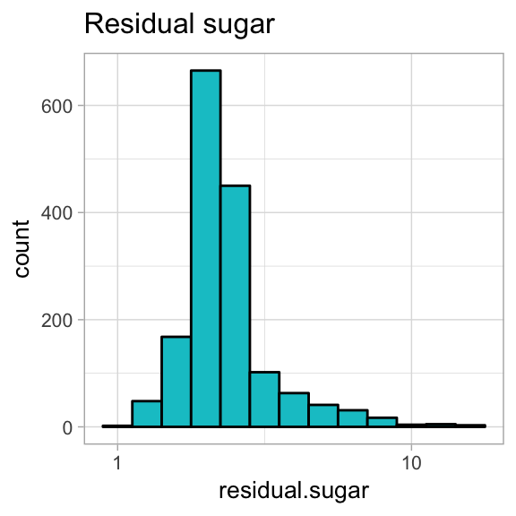

Figure 3.3: Residual sugar distribution

### 3.1.4 Chlorides and sulfur dioxide

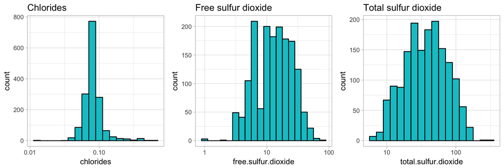

Figure 3.4: Chlorides and sulfur dioxide distributions

### 3.1.5 Density, pH, sulphates and alcohol

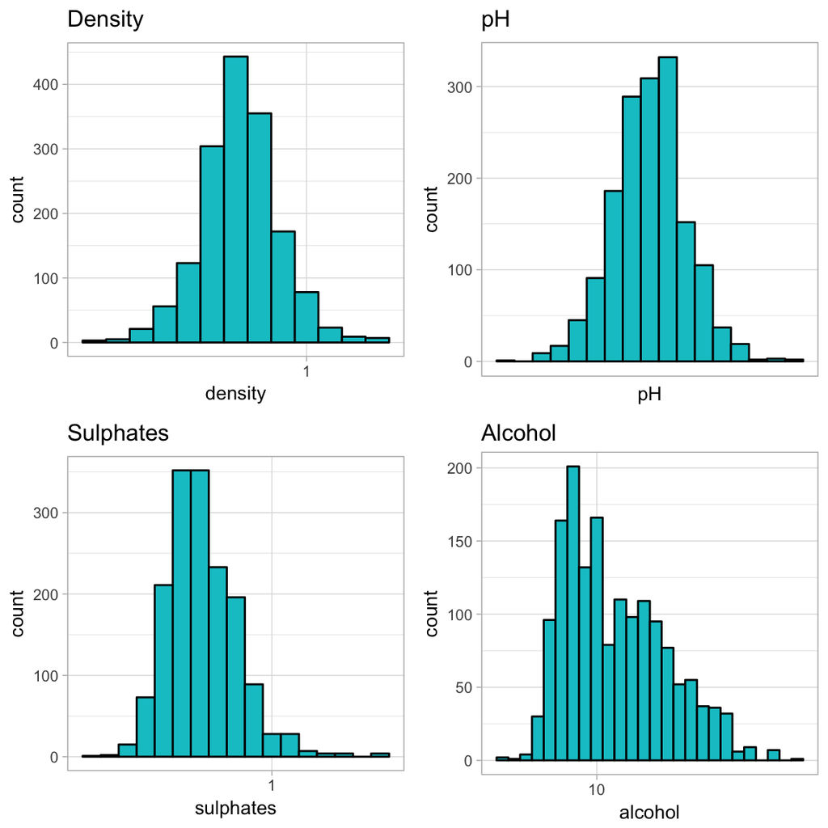

Figure 3.5: Density, pH, sulphates and alcohol distributions

## 3.2 Analysis

### 3.2.1 What is the structure of your dataset?

There are 1599 red wines with *12 features* (**fixed.acidity, volatile.acidity, citric.acid, residual.sugar, chlorides, free.sulfur.dioxide, total.sulfur.dioxide, density, pH, sulphates, alcohol** and **quality**). The variables quality is converted in a factor variable (adding a new variable named `quality.cat`) with the following levels:

Quality range table.

|  | BAD | MEDIUM | GOOD |
| --- | --- | --- | --- |
| `quality.cat` | [0,4] | (4,7) | [7,10] |

Other observations:

Table 3.1: Summary of `redwines.quality`

|  | Min. | 1st Qu. | Median | Mean | 3rd Qu. | Max. |
| --- | --- | --- | --- | --- | --- | --- |
| `redwines.quality` | 3 | 5 | 6 | 5.636 | 6 | 8 |

Table 3.1 shows that the mean quality of the red wines is 5.636 and the median is 6. Q1 division corresponds to 5 and Q3 to 6, hence, 50% of the data lays within 5-6 range of quality, this is the level MEDIUM.

### 3.2.2 What is/are the main feature(s) of interest in your dataset?

The main feature of interest in this dataset is the **quality** of the wine.

### 3.2.3 What other features in the dataset do you think will help support your investigation into your feature(s) of interest?

In Cortez et al. (2009) it is shown that the most imporant features for assessing Red Wine quality are: **sulphates**, **pH** and **total sulfur dioxide**. An analysis will be performed in order to certify whether these are the most importart features for the analysis or others are.

### 3.2.5 Of the features you investigated, were there any unusual distributions? Did you perform any operations on the data to tidy, adjust, or change the form of the data? If so, why did you do this?

Most of the features had a normal distribution. Some of the them had quite skewed distributions and many oultiers and I performed a log10 tranformation in order to have a better view. The efect of this transformation can be observed in figure 3.6, where charateristics of plots in the left side are seen better after the x axis is transformed.

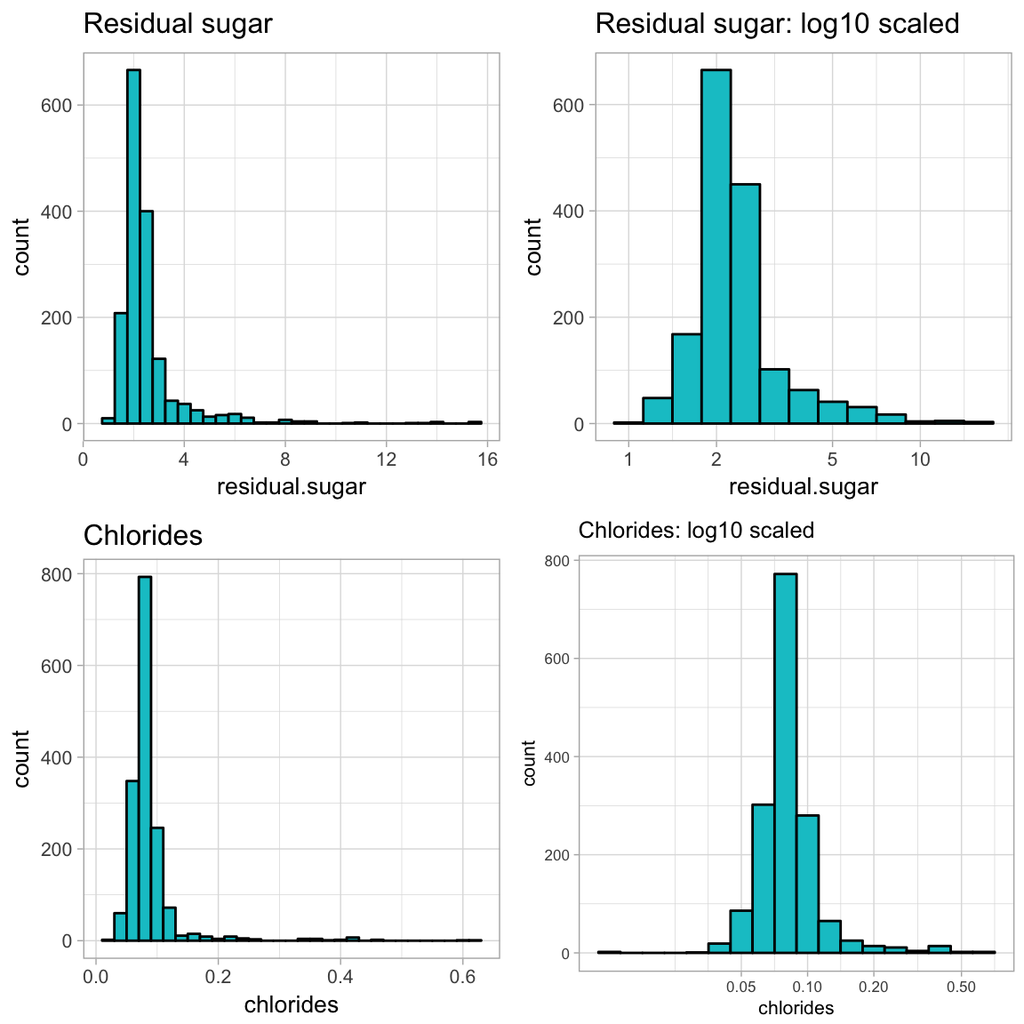

Figure 3.6: Residual sugar and Chlorides distributions with original and log10() transformed axis

# 4 Bivariate Analysis

## 4.1 Plots Section

In this section it will be perfomed an analysis of the features vs the quality ranges.

### 4.1.1 Fixed and volatile acidity

In the next plot (fig.4.1) it is deduced that the quality of the wine is directly proportional to the fixed acidity and acid levels and inversely proportional to volatile acidity.

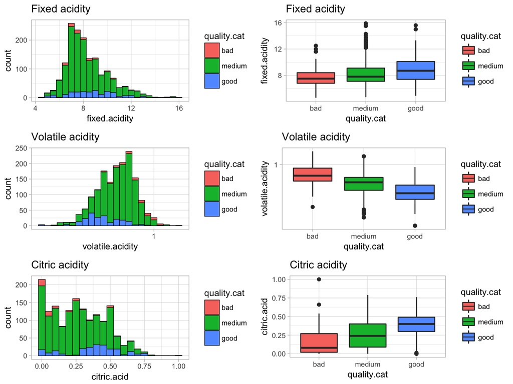

Figure 4.1: Fixed and volatile acidity distributions per quality segment

### 4.1.2 Residual sugar

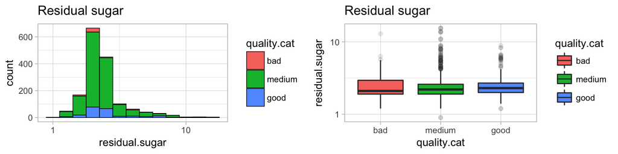

Figure 4.2: Residual sugar distribution per quality segment

### 4.1.3 Chlorides and sulfur dioxide

In the plot of the chlorides, it can be onserved that the better the wine, the lower the chloride levels. For the sulfur dioxide, either the free or the total sulfur dioxide, high levels are indicator of medium quality, whereas bad and good wine have the same low amount of sulfure dioxide.

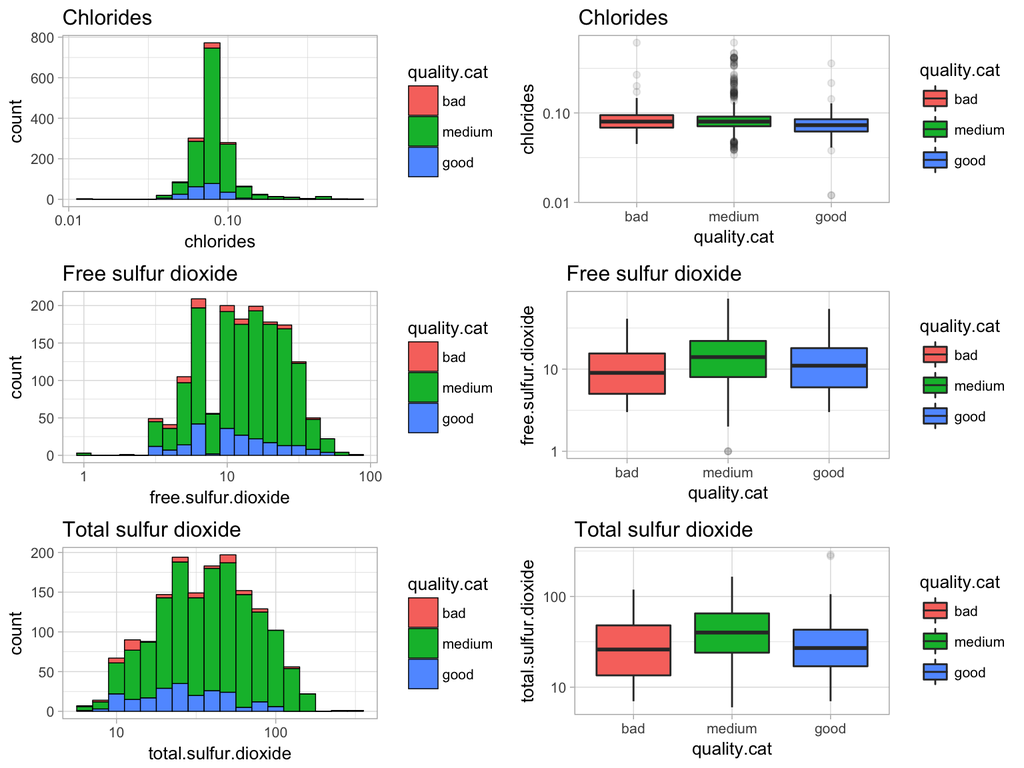

Figure 4.3: Chlorides and sulfur dioxide distributions per quality segment

### 4.1.4 Density, pH, sulphates and alcohol

The next plot shows that, generally, the lower the density, the better the quality of the wine. Also, low pH levels are sign of beter quality. The higher the sulphates level, the better quality of the wine and also, good wines have higher amount of alcohol.

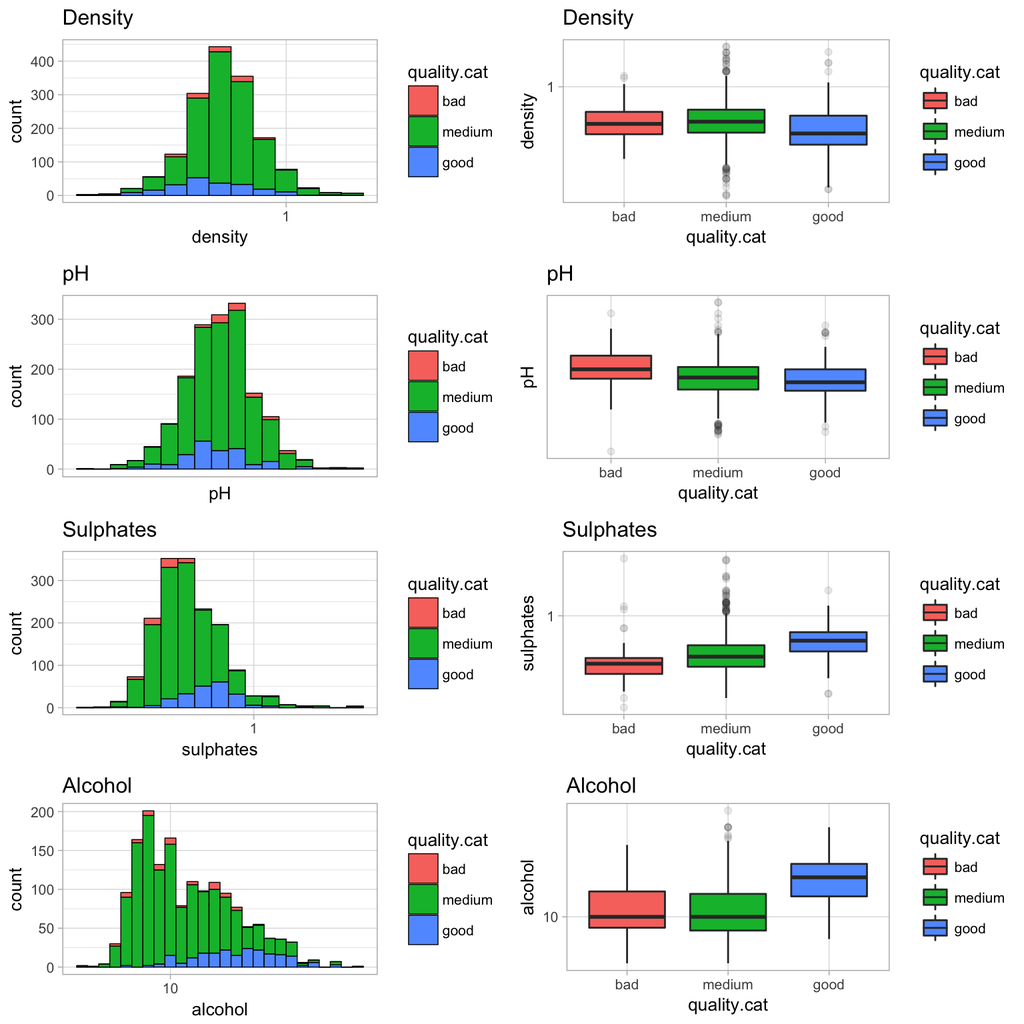

Figure 4.4: Density, pH, suplhates and alcohol distributions per quality segment

### 4.1.5 Matrix of feature relationships

[figure not shown]

## 4.2 Bivariate Analysis

### 4.2.1 Talk about some of the relationships you observed in this part of the investigation. How did the feature(s) of interest vary with other features in the dataset?

### 4.2.2 Did you observe any interesting relationships between the other features (not the main feature(s) of interest)?

### 4.2.3 What was the strongest relationship you found?

# 5 Multivariate Plots Section

## 5.1 Correlation

### 5.1.1 Correlation betweeen variables

For the purpose of this analysis, the focus will be placed in the relationship between quality and other variables.

### 5.1.2 Correlation between variables by quality range

Let us now analyze the correlation between the variables for each quality range in figure 5.1. It can be seen that features are more correlated between them for *lower* quality wine. Some strong relationships between variables are kept for all quality ranges, as pH-density, pH-citric acid and ph-fixed acidity, or fixed acid-volatile acidity and fixed acid-fixed acidity.

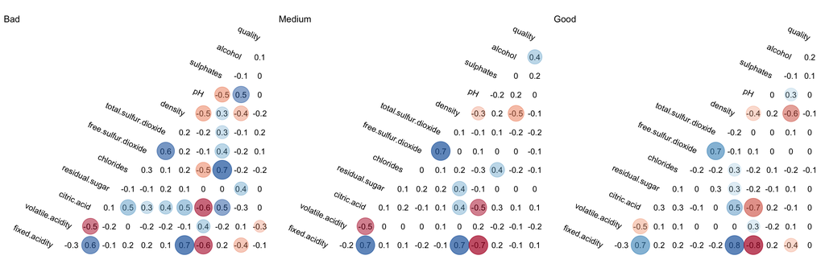

Figure 5.1: Correlation vs Quality

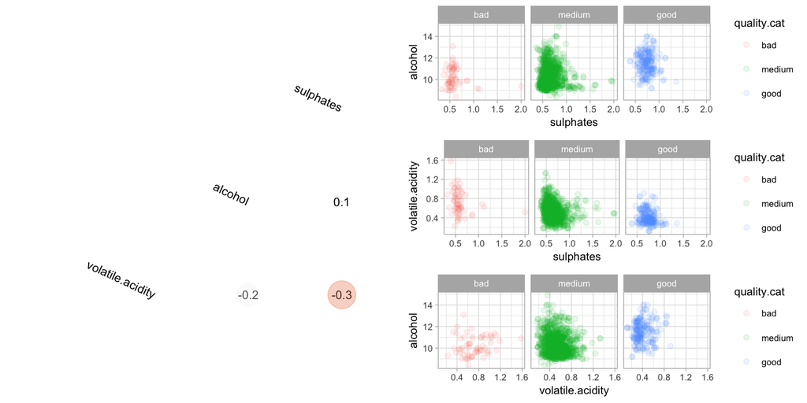

Figure 5.2: Correlation between alcohol, volatile acidity and sulphates

Let us now explore the three variables suggested in Cortez et al. (2009) as the most imporant features for assessing Red Wine quality are: **sulphates**, **pH** and **total sulfur dioxide**.

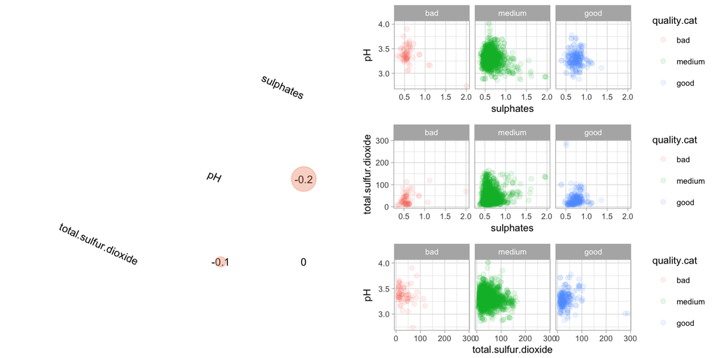

Figure 5.3: Correlation between total sulfur dioxide, pH and sulphates

From figure 5.3 and 5.2 it can be concluded the varibles in the second figure (**sulphates**, **pH** and **total sulfur dioxide**), the ones suggested by Cortez et al. (2009) are less correlated between them and lead to a more accurate analysis.

# 6 Multivariate Analysis

### 6.0.1 Talk about some of the relationships you observed in this part of the investigation. Were there features that strengthened each other in terms of looking at your feature(s) of interest?

### 6.0.2 Were there any interesting or surprising interactions between features?

### 6.0.3 OPTIONAL: Did you create any models with your dataset? Discuss the strengths and limitations of your model.

## 6.1

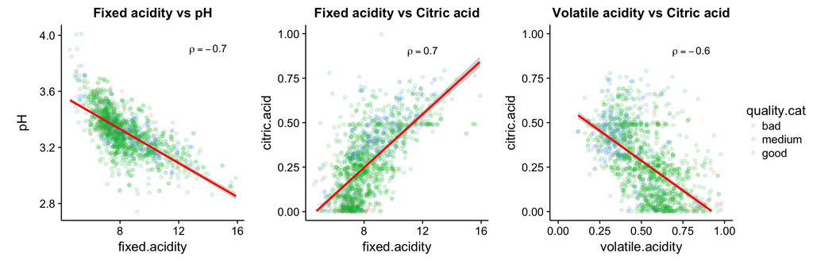

# 7 Final Plots and Summary

# 8 Reflection

## References

Cortez, Paulo, António Cerdeira, Fernando Almeida, Telmo Matos, and José Reis. 2009. “Modeling Wine Preferences by Data Mining from Physicochemical Properties.” *Decision Support Systems* 47 (4). Elsevier: 547–53.